# DATA621 - Hospitals

Daniel Hong, Mauricio Alarcon, Maxwell Wagner

Nov 15, 2016

## 1. DATA EXPLORATION (25 Points)

Describe the size and the variables in the insurance training data set. Consider that too much detail will cause a manager to lose interest while too little detail will make the manager consider that you arenât doing your job. Some suggestions are given below. Please do NOT treat this as a check list of things to do to complete the assignment. You should have your own thoughts on what to tell the boss. These are just ideas.

1. Mean / Standard Deviation / Median
2. Bar Chart or Box Plot of the data
3. Is the data correlated to the target variable (or to other variables?)
4. Are any of the variables missing and need to be imputed âfixedâ?
1. Mean / Standard Deviation / Median

```r
#require("plyr")
require("knitr")
require("psych")
# Let's load the data
#detach(package:plyr)
require("dplyr")
coalesce <- function(...) {
  apply(cbind(...), 1, function(x) {
          x[which(!is.na(x))[1]]
        })
}

hcahps <- rbind(read.csv(url('https://raw.githubusercontent.com/rmalarc/DATA621/master/final/HCAHPS - Hospital.csv'),stringsAsFactors = FALSE),read.csv(url('https://raw.githubusercontent.com/rmalarc/DATA621/master/final/HCAHPS - Hospital2.csv'),stringsAsFactors = FALSE))

unique(hcahps$HCAHPS.Question)
```

```
##  [1] "Summary star rating"
##  [2] "Patients who reported that their room and bathroom were \"Always\" clean"
##  [3] "Patients who reported that their room and bathroom were \"Sometimes\" or \"Never\" clean"
##  [4] "Patients who reported that their room and bathroom were \"Usually\" clean"
##  [5] "Cleanliness - linear mean score"
##  [6] "Cleanliness - star rating"
##  [7] "Patients who reported that their nurses \"Always\" communicated well"
##  [8] "Nurse communication - linear mean score"
##  [9] "Patients who reported that their nurses \"Sometimes\" or \"Never\" communicated well"
## [10] "Nurse communication - star rating"
## [11] "Patients who reported that their nurses \"Usually\" communicated well"
## [12] "Patients who reported that their doctors \"Always\" communicated well"
## [13] "Doctor communication - linear mean score"
## [14] "Patients who reported that their doctors \"Sometimes\" or \"Never\" communicated well"
## [15] "Doctor communication - star rating"
```

[output cut: 40 more lines]

```r
unique(unlist(c(hcahps$Patient.Survey.Star.Rating.Footnote,hcahps$HCAHPS.Answer.Percent.Footnote,hcahps$Survey.Response.Rate.Percent.Footnote,hcahps$Number.of.Completed.Surveys.Footnote)))
```

```
##  [1] ""
##  [2] "15 - The number of cases/patients is too few to report a star rating."
##  [3] "5 - Results are not available for this reporting period."
##  [4] "19 - Data are shown only for hospitals that participate in the Inpatient Quality Reporting (IQR) and Outpatient Quality Reporting (OQR) programs."
##  [5] "3 - Results are based on a shorter time period than required., 11 - There were discrepancies in the data collection process."
##  [6] "3 - Results are based on a shorter time period than required., 10 - Very few patients were eligible for the HCAHPS survey. The scores shown reflect fewer than 50 completed surveys. Use these scores with caution, as the number of surveys may be too low to reliably assess hospital performance…
##  [7] "6 - Fewer than 100 patients completed the HCAHPS survey. Use these scores with caution, as the number of surveys may be too low to reliably assess hospital performance."
##  [8] "10 - Very few patients were eligible for the HCAHPS survey. The scores shown reflect fewer than 50 completed surveys. Use these scores with caution, as the number of surveys may be too low to reliably assess hospital performance., 11 - There were discrepancies in the data collection process…
##  [9] "10 - Very few patients were eligible for the HCAHPS survey. The scores shown reflect fewer than 50 completed surveys. Use these scores with caution, as the number of surveys may be too low to reliably assess hospital performance."
## [10] "6 - Fewer than 100 patients completed the HCAHPS survey. Use these scores with caution, as the number of surveys may be too low to reliably assess hospital performance., 11 - There were discrepancies in the data collection process."
## [11] "11 - There were discrepancies in the data collection process."
## [12] "1 - The number of cases/patients is too few to report."
## [13] "3 - Results are based on a shorter time period than required., 10 - Very few patients were eligible for the HCAHPS survey. The scores shown reflect fewer than 50 completed surveys. Use these scores with caution, as the number of surveys may be too low to reliably assess hospital performance…
## [14] "3 - Results are based on a shorter time period than required., 6 - Fewer than 100 patients completed the HCAHPS survey. Use these scores with caution, as the number of surveys may be too low to reliably assess hospital performance., 11 - There were discrepancies in the data collection proce…
## [15] "3 - Results are based on a shorter time period than required., 6 - Fewer than 100 patients completed the HCAHPS survey. Use these scores with caution, as the number of surveys may be too low to reliably assess hospital performance."
```

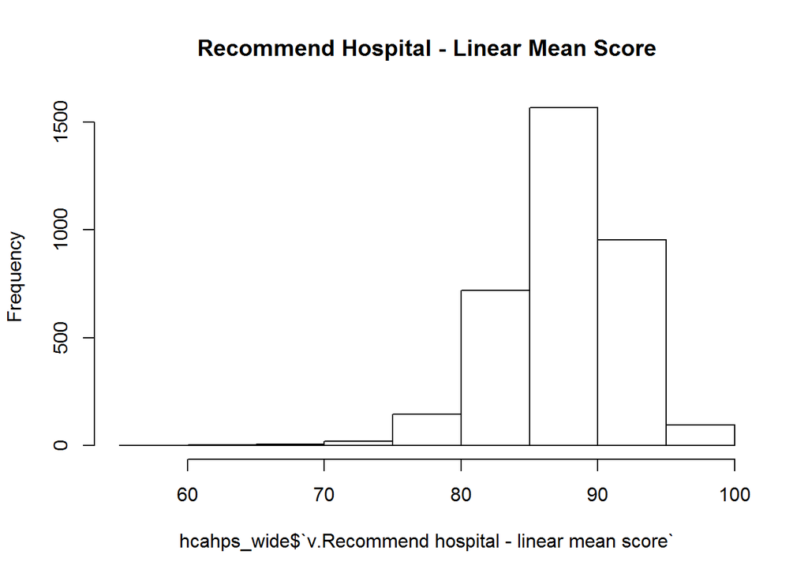

```r
hcahps_lms <- hcahps[grep("(linear mean score)",hcahps$HCAHPS.Question),] #|Summary star rating
hcahps_lms$v <- coalesce(as.numeric(hcahps_lms$Patient.Survey.Star.Rating),as.numeric(hcahps_lms$HCAHPS.Linear.Mean.Value)) #,as.numeric(hcahps$HCAHPS.Answer.Percent),

hcahps_wide<-reshape(hcahps_lms[,c("Provider.ID", "Survey.Response.Rate.Percent","HCAHPS.Question","v")],
  timevar = "HCAHPS.Question",
  idvar = c("Provider.ID", "Survey.Response.Rate.Percent"),
  direction = "wide")
#hcahps_wide<-hcahps_wide[complete.cases(hcahps_wide),]

#hist(hcahps_wide$`v.Summary star rating`,main="Summary Star Rating")
#mean(hcahps_wide$`v.Summary star rating`,na.rm = T)
#sd(hcahps_wide$`v.Summary star rating`,na.rm = T)

hist(hcahps_wide$`v.Recommend hospital - linear mean score`,main="Recommend Hospital - Linear Mean Score")
```

```r
mean(hcahps_wide$`v.Recommend hospital - linear mean score`,na.rm = T)
```

```
## [1] 88.03278
```

```r
sd(hcahps_wide$`v.Recommend hospital - linear mean score`,na.rm = T)
```

```
## [1] 4.371318
```

```r
general_info <- read.csv(url('https://raw.githubusercontent.com/rmalarc/DATA621/master/final/Hospital General Information.csv'),stringsAsFactors = FALSE)

colnames(general_info)
```

```
##  [1] "Provider.ID"
##  [2] "Hospital.Name"
##  [3] "Address"
##  [4] "City"
##  [5] "State"
##  [6] "ZIP.Code"
##  [7] "County.Name"
##  [8] "Phone.Number"
##  [9] "Hospital.Type"
## [10] "Hospital.Ownership"
## [11] "Emergency.Services"
## [12] "Meets.criteria.for.meaningful.use.of.EHRs"
## [13] "Hospital.overall.rating"
## [14] "Hospital.overall.rating.footnote"
## [15] "Mortality.national.comparison"
## [16] "Mortality.national.comparison.footnote"
## [17] "Safety.of.care.national.comparison"
## [18] "Safety.of.care.national.comparison.footnote"
## [19] "Readmission.national.comparison"
## [20] "Readmission.national.comparison.footnote"
## [21] "Patient.experience.national.comparison"
## [22] "Patient.experience.national.comparison.footnote"
## [23] "Effectiveness.of.care.national.comparison"
## [24] "Effectiveness.of.care.national.comparison.footnote"
## [25] "Timeliness.of.care.national.comparison"
## [26] "Timeliness.of.care.national.comparison.footnote"
## [27] "Efficient.use.of.medical.imaging.national.comparison"
## [28] "Efficient.use.of.medical.imaging.national.comparison.footnote"
```

```r
summary(general_info)
```

```
##   Provider.ID     Hospital.Name        Address              City
##  Min.   : 10001   Length:4818        Length:4818        Length:4818
##  1st Qu.:140185   Class :character   Class :character   Class :character
##  Median :260037   Mode  :character   Mode  :character   Mode  :character
##  Mean   :267984
##  3rd Qu.:390209
##  Max.   :670112
##     State              ZIP.Code     County.Name         Phone.Number
##  Length:4818        Min.   :  603   Length:4818        Min.   :9.369e+08
##  Class :character   1st Qu.:33014   Class :character   1st Qu.:4.018e+09
##  Mode  :character   Median :55396   Mode  :character   Median :6.053e+09
##                     Mean   :53956                      Mean   :5.849e+09
##                     3rd Qu.:76019                      3rd Qu.:7.878e+09
##                     Max.   :99929                      Max.   :9.899e+09
##  Hospital.Type      Hospital.Ownership Emergency.Services
##  Length:4818        Length:4818        Length:4818
##  Class :character   Class :character   Class :character
##  Mode  :character   Mode  :character   Mode  :character
##
##
##
##  Meets.criteria.for.meaningful.use.of.EHRs Hospital.overall.rating
##  Length:4818                               Length:4818
##  Class :character                          Class :character
##  Mode  :character                          Mode  :character
##
##
##
##  Hospital.overall.rating.footnote Mortality.national.comparison
##  Length:4818                      Length:4818
##  Class :character                 Class :character
##  Mode  :character                 Mode  :character
##
##
##
##  Mortality.national.comparison.footnote Safety.of.care.national.comparison
##  Length:4818                            Length:4818
##  Class :character                       Class :character
##  Mode  :character                       Mode  :character
##
```

[output cut: 57 more lines]

```
##
##  Efficient.use.of.medical.imaging.national.comparison
##  Length:4818
##  Class :character
##  Mode  :character
##
##
##
##  Efficient.use.of.medical.imaging.national.comparison.footnote
##  Length:4818
##  Class :character
##  Mode  :character
##
##
##
```

```r
sapply(general_info[,c("Hospital.Type"
,"Hospital.Ownership"
,"Emergency.Services"
,"Hospital.overall.rating"
,"Mortality.national.comparison"
,"Safety.of.care.national.comparison"
,"Readmission.national.comparison"
,"Effectiveness.of.care.national.comparison"
,"Timeliness.of.care.national.comparison"
,"Efficient.use.of.medical.imaging.national.comparison")], unique)
```

```
## $Hospital.Type
## [1] "Acute Care Hospitals"      "Critical Access Hospitals"
## [3] "Childrens"
##
## $Hospital.Ownership
##  [1] "Government - Hospital District or Authority"
##  [2] "Voluntary non-profit - Private"
##  [3] "Proprietary"
##  [4] "Government - State"
##  [5] "Voluntary non-profit - Other"
##  [6] "Government - Local"
##  [7] "Voluntary non-profit - Church"
##  [8] "Government - Federal"
##  [9] "Tribal"
## [10] "Physician"
##
## $Emergency.Services
## [1] "Yes" "No"
##
## $Hospital.overall.rating
## [1] "3"             "2"             "Not Available" "4"
## [5] "5"             "1"
##
## $Mortality.national.comparison
## [1] "Same as the National average" "Below the National average"
## [3] "Not Available"                "Above the National average"
##
## $Safety.of.care.national.comparison
## [1] "Above the National average"   "Same as the National average"
## [3] "Not Available"                "Below the National average"
##
## $Readmission.national.comparison
## [1] "Same as the National average" "Above the National average"
## [3] "Below the National average"   "Not Available"
##
## $Effectiveness.of.care.national.comparison
## [1] "Same as the National average" "Below the National average"
## [3] "Above the National average"   "Not Available"
##
## $Timeliness.of.care.national.comparison
## [1] "Same as the National average" "Above the National average"
## [3] "Below the National average"   "Not Available"
##
## $Efficient.use.of.medical.imaging.national.comparison
## [1] "Same as the National average" "Below the National average"
## [3] "Not Available"                "Above the National average"
```

```r
training <- merge(hcahps_wide, general_info[,c("Provider.ID"
,"Hospital.Type"
,"Hospital.Ownership"
,"Emergency.Services"
,"Hospital.overall.rating"
,"Mortality.national.comparison"
,"Safety.of.care.national.comparison"
,"Readmission.national.comparison"
,"Effectiveness.of.care.national.comparison"
,"Timeliness.of.care.national.comparison"
,"Efficient.use.of.medical.imaging.national.comparison")], by="Provider.ID")

sapply(general_info, function(x){length(x[x=="Not Available"])})
```

```
##                                                   Provider.ID
##                                                             0
##                                                 Hospital.Name
##                                                             0
##                                                       Address
##                                                             0
##                                                          City
##                                                             0
##                                                         State
##                                                             0
##                                                      ZIP.Code
##                                                             0
##                                                   County.Name
##                                                             0
##                                                  Phone.Number
##                                                             0
##                                                 Hospital.Type
##                                                             0
##                                            Hospital.Ownership
##                                                             0
##                                            Emergency.Services
##                                                             0
##                     Meets.criteria.for.meaningful.use.of.EHRs
##                                                             0
##                                       Hospital.overall.rating
##                                                          1170
##                              Hospital.overall.rating.footnote
##                                                             0
##                                 Mortality.national.comparison
##                                                          1337
##                        Mortality.national.comparison.footnote
##                                                             0
##                            Safety.of.care.national.comparison
##                                                          1892
##                   Safety.of.care.national.comparison.footnote
##                                                             0
##                               Readmission.national.comparison
##                                                          1002
##                      Readmission.national.comparison.footnote
##                                                             0
##                        Patient.experience.national.comparison
##                                                          1355
##               Patient.experience.national.comparison.footnote
##                                                             0
##                     Effectiveness.of.care.national.comparison
##                                                          1116
##            Effectiveness.of.care.national.comparison.footnote
##                                                             0
##                        Timeliness.of.care.national.comparison
##                                                          1331
##               Timeliness.of.care.national.comparison.footnote
##                                                             0
##          Efficient.use.of.medical.imaging.national.comparison
##                                                          2026
## Efficient.use.of.medical.imaging.national.comparison.footnote
##                                                             0
```

```r
training$Hospital.overall.rating <- ifelse(training$Hospital.overall.rating=="Not Available",NA,training$Hospital.overall.rating)
training$Mortality.national.comparison <- ifelse(training$Mortality.national.comparison=="Not Available",NA,training$Mortality.national.comparison)
training$Safety.of.care.national.comparison <- ifelse(training$Safety.of.care.national.comparison=="Not Available",NA,training$Safety.of.care.national.comparison)
training$Readmission.national.comparison <- ifelse(training$Readmission.national.comparison=="Not Available",NA,training$Readmission.national.comparison)
training$Effectiveness.of.care.national.comparison <- ifelse(training$Effectiveness.of.care.national.comparison=="Not Available",NA,training$Effectiveness.of.care.national.comparison)
training$Timeliness.of.care.national.comparison <- ifelse(training$Timeliness.of.care.national.comparison=="Not Available",NA,training$Timeliness.of.care.national.comparison)
training$Efficient.use.of.medical.imaging.national.comparison <- ifelse(training$Efficient.use.of.medical.imaging.national.comparison=="Not Available",NA,training$Efficient.use.of.medical.imaging.national.comparison)


columns <- colnames(training)
target <- c("v.Recommend hospital - linear mean score") #"v.Summary star rating",
inputs <- columns[!columns %in% c(target,"Provider.ID")]


summary <- describe(training[,c(target,inputs)],na.rm = TRUE)[,c("n","mean","sd","median","min","max")]
summary$completeness <- summary$n/nrow(training)
summary$cv <- 100*summary$sd/summary$mean

kable(summary)
```

|  | n | mean | sd | median | min | max | completeness | cv |
| --- | --- | --- | --- | --- | --- | --- | --- | --- |
| v.Recommend hospital - linear mean score | 3508 | 88.03278 | 4.371318 | 89 | 59 | 100 | 0.7281029 | 4.965557 |
| Survey.Response.Rate.Percent* | 4818 | NaN | NA | NA | Inf | -Inf | 1.0000000 | NA |
| v.Cleanliness - linear mean score | 3508 | 87.29333 | 3.862299 | 87 | 71 | 99 | 0.7281029 | 4.424507 |
| v.Nurse communication - linear mean score | 3508 | 91.32754 | 2.535669 | 92 | 73 | 100 | 0.7281029 | 2.776456 |
| v.Doctor communication - linear mean score | 3508 | 91.89937 | 2.443749 | 92 | 75 | 100 | 0.7281029 | 2.659157 |
| v.Staff responsiveness - linear mean score | 3508 | 85.27509 | 4.396370 | 85 | 64 | 99 | 0.7281029 | 5.155515 |
| v.Pain management - linear mean score | 3508 | 87.56870 | 2.586978 | 88 | 70 | 100 | 0.7281029 | 2.954227 |
| v.Communication about medicines - linear mean score | 3508 | 78.78022 | 4.287353 | 79 | 58 | 95 | 0.7281029 | 5.442169 |
| v.Discharge information - linear mean score | 3508 | 86.90165 | 3.558508 | 87 | 62 | 99 | 0.7281029 | 4.094868 |
| v.Care transition - linear mean score | 3508 | 81.52651 | 2.871675 | 82 | 64 | 99 | 0.7281029 | 3.522382 |
| v.Overall hospital rating - linear mean score | 3508 | 88.72605 | 3.253992 | 89 | 65 | 99 | 0.7281029 | 3.667459 |
| v.Quietness - linear mean score | 3508 | 83.04989 | 5.110869 | 83 | 60 | 98 | 0.7281029 | 6.153974 |
| Hospital.Type* | 4818 | NaN | NA | NA | Inf | -Inf | 1.0000000 | NA |
| Hospital.Ownership* | 4818 | NaN | NA | NA | Inf | -Inf | 1.0000000 | NA |
| Emergency.Services* | 4818 | NaN | NA | NA | Inf | -Inf | 1.0000000 | NA |
| Hospital.overall.rating* | 3648 | NaN | NA | NA | Inf | -Inf | 0.7571606 | NA |
| Mortality.national.comparison* | 3481 | NaN | NA | NA | Inf | -Inf | 0.7224990 | NA |
| Safety.of.care.national.comparison* | 2926 | NaN | NA | NA | Inf | -Inf | 0.6073059 | NA |
| Readmission.national.comparison* | 3816 | NaN | NA | NA | Inf | -Inf | 0.7920299 | NA |
| Effectiveness.of.care.national.comparison* | 3702 | NaN | NA | NA | Inf | -Inf | 0.7683686 | NA |
| Timeliness.of.care.national.comparison* | 3487 | NaN | NA | NA | Inf | -Inf | 0.7237443 | NA |
| Efficient.use.of.medical.imaging.national.comparison* | 2792 | NaN | NA | NA | Inf | -Inf | 0.5794936 | NA |

```r
head(training)
```

```
##   Provider.ID Survey.Response.Rate.Percent
## 1       10001                           27
## 2       10005                           36
## 3       10006                           25
## 4       10007                           33
## 5       10008                           31
## 6       10011                           28
##   v.Cleanliness - linear mean score
## 1                                84
## 2                                83
## 3                                83
## 4                                89
## 5                                NA
## 6                                81
##   v.Nurse communication - linear mean score
```

[output cut: 104 more lines]

```r
summary(training)
```

```
##   Provider.ID     Survey.Response.Rate.Percent
##  Min.   : 10001   Length:4818
##  1st Qu.:140185   Class :character
##  Median :260037   Mode  :character
##  Mean   :267984
##  3rd Qu.:390209
##  Max.   :670112
##
##  v.Cleanliness - linear mean score
##  Min.   :71.00
##  1st Qu.:85.00
##  Median :87.00
##  Mean   :87.29
##  3rd Qu.:90.00
##  Max.   :99.00
##  NA's   :1310
##  v.Nurse communication - linear mean score
##  Min.   : 73.00
##  1st Qu.: 90.00
##  Median : 92.00
##  Mean   : 91.33
##  3rd Qu.: 93.00
##  Max.   :100.00
##  NA's   :1310
##  v.Doctor communication - linear mean score
##  Min.   : 75.0
##  1st Qu.: 90.0
##  Median : 92.0
##  Mean   : 91.9
##  3rd Qu.: 93.0
##  Max.   :100.0
##  NA's   :1310
##  v.Staff responsiveness - linear mean score
##  Min.   :64.00
##  1st Qu.:83.00
##  Median :85.00
##  Mean   :85.28
##  3rd Qu.:88.00
##  Max.   :99.00
##  NA's   :1310
```

[output cut: 81 more lines]

```
##  Length:4818
##  Class :character
##  Mode  :character
##
##
##
##
##  Efficient.use.of.medical.imaging.national.comparison
##  Length:4818
##  Class :character
##  Mode  :character
##
##
##
##
```

## 2. DATA PREPARATION (25 Points)

Describe how you have transformed the data by changing the original variables or creating new variables. If you did transform the data or create new variables, discuss why you did this. Here are some possible transformations.

1. Fix missing values (maybe with a Mean or Median value)
2. Create flags to suggest if a variable was missing
3. Transform data by putting it into buckets
4. Mathematical transforms such as log or square root (or use Box-Cox)
5. Combine variables (such as ratios or adding or multiplying) to create new variables

### Data Transformations

```r
training<-training[complete.cases(training),]

transform <- function(d){
  d['TARGET_NUM'] <- as.numeric(d["v.Recommend hospital - linear mean score"])
  d['SURVEY_RESPONSE_RATE'] <- as.numeric(d["Survey.Response.Rate.Percent"])
  d['CLEANLINESS'] <- as.numeric(d["v.Cleanliness - linear mean score"])
  d['NURSE_COMMUNICATION'] <- as.numeric(d["v.Nurse communication - linear mean score"])
  d['DOCTOR_COMMUNICATION'] <- as.numeric(d["v.Doctor communication - linear mean score"])
  d['STAFF_RESPONSIVENESS'] <- as.numeric(d["v.Staff responsiveness - linear mean score"])
  d['PAIN_MANAGEMENT'] <- as.numeric(d["v.Pain management - linear mean score"])
  d['MEDICATION_COMMUNICATION'] <- as.numeric(d["v.Communication about medicines - linear mean score"])
  d['DISCHARGE_INFO'] <- as.numeric(d["v.Discharge information - linear mean score"])
  d['CARE_TRANSITION'] <- as.numeric(d["v.Care transition - linear mean score"])
  d['HOSPITAL_RATING'] <- as.numeric(d["v.Overall hospital rating - linear mean score"])
  d['QUIETNESS'] <- as.numeric(d["v.Quietness - linear mean score"])
  outputCols<- c('TARGET_NUM','SURVEY_RESPONSE_RATE','CLEANLINESS','NURSE_COMMUNICATION','DOCTOR_COMMUNICATION','STAFF_RESPONSIVENESS','PAIN_MANAGEMENT','MEDICATION_COMMUNICATION','DISCHARGE_INFO','CARE_TRANSITION','HOSPITAL_RATING','QUIETNESS')

  #d['TYPE_ACUTE_CARE_HOSPITALS_BIN'] <- if (d['Hospital.Type']=="Acute Care Hospitals") {1} else {0}
  #outputCols <- c(outputCols,'TYPE_ACUTE_CARE_HOSPITALS_BIN')

  d['TYPE_CRITICAL_ACCESS_HOSPITALS_BIN'] <- if (d['Hospital.Type']=="Critical Access Hospitals") {1} else {0}
  outputCols <- c(outputCols,'TYPE_CRITICAL_ACCESS_HOSPITALS_BIN')

  d['TYPE_CHILDRENS_BIN'] <- if (d['Hospital.Type']=="Childrens") {1} else {0}
  outputCols <- c(outputCols,'TYPE_CHILDRENS_BIN')

  #d['OWNERSHIP_GOV_DISTRICT_BIN'] <- if (d['Hospital.Ownership']=="Government - Hospital District or Authority") {1} else {0}
  d['OWNERSHIP_PRIVATE_BIN'] <- if (d['Hospital.Ownership']=="Voluntary non-profit - Private") {1} else {0}
  d['OWNERSHIP_PROPRIETARY_BIN'] <- if (d['Hospital.Ownership']=="Proprietary") {1} else {0}
  d['OWNERSHIP_GOV_STATE_BIN'] <- if (d['Hospital.Ownership']=="Government - State") {1} else {0}
  d['OWNERSHIP_OTHER_BIN'] <- if (d['Hospital.Ownership']=="Voluntary non-profit - Other") {1} else {0}
  d['OWNERSHIP_GOV_LOCAL_BIN'] <- if (d['Hospital.Ownership']=="Government - Local") {1} else {0}
  d['OWNERSHIP_CHURCH_BIN'] <- if (d['Hospital.Ownership']=="Voluntary non-profit - Church") {1} else {0}
  d['OWNERSHIP_GOV_FEDERAL_BIN'] <- if (d['Hospital.Ownership']=="Government - Federal") {1} else {0}
  d['OWNERSHIP_TRIBAL_BIN'] <- if (d['Hospital.Ownership']=="Tribal") {1} else {0}
  d['OWNERSHIP_PHYSICIAN_BIN'] <- if (d['Hospital.Ownership']=="Physician") {1} else {0}
  outputCols <- c(outputCols,'OWNERSHIP_PRIVATE_BIN','OWNERSHIP_PROPRIETARY_BIN','OWNERSHIP_GOV_STATE_BIN','OWNERSHIP_OTHER_BIN','OWNERSHIP_GOV_LOCAL_BIN','OWNERSHIP_CHURCH_BIN','OWNERSHIP_GOV_FEDERAL_BIN','OWNERSHIP_TRIBAL_BIN','OWNERSHIP_PHYSICIAN_BIN')

  d['EMERGENCY_SVC_BIN'] <- if (d['Emergency.Services']=='Yes') {1} else {0}
  outputCols <- c(outputCols,'EMERGENCY_SVC_BIN')

  d['HOSPITAL_OVERALL_RTG'] <- as.numeric(d['Hospital.overall.rating'])
  outputCols <- c(outputCols,'HOSPITAL_OVERALL_RTG')

  d['MORTALITY_SAME_NTL_BIN'] <- if (d['Mortality.national.comparison']=="Same as the National average") {1} else {0}
  d['MORTALITY_ABOVE_NTL_BIN'] <- if (d['Mortality.national.comparison']=="Above the National average") {1} else {0}
  d['SAFETY_OF_CARE_SAME_NTL_BIN'] <- if (d['Safety.of.care.national.comparison']=="Same as the National average") {1} else {0}
  d['SAFETY_OF_CARE_ABOVE_NTL_BIN'] <- if (d['Safety.of.care.national.comparison']=="Above the National average") {1} else {0}
  d['READM_SAME_NTL_BIN'] <- if (d['Readmission.national.comparison']=="Same as the National average") {1} else {0}
  d['READM_ABOVE_NTL_BIN'] <- if (d['Readmission.national.comparison']=="Above the National average") {1} else {0}
  d['EFFECTIVENESS_OF_CARE_SAME_NTL_BIN'] <- if (d['Effectiveness.of.care.national.comparison']=="Same as the National average") {1} else {0}
  d['EFFECTIVENESS_OF_CARE_ABOVE_NTL_BIN'] <- if (d['Effectiveness.of.care.national.comparison']=="Above the National average") {1} else {0}
  d['TIMELINESS_OF_CARE_SAME_NTL_BIN'] <- if (d['Timeliness.of.care.national.comparison']=="Same as the National average") {1} else {0}
  d['TIMELINESS_OF_CARE_ABOVE_NTL_BIN'] <- if (d['Timeliness.of.care.national.comparison']=="Above the National average") {1} else {0}
  d['EFFICIENCY_OF_USE_MEDICAL_IMAGING_EQUIPMENT_SAME_NTL_BIN'] <- if (d['Efficient.use.of.medical.imaging.national.comparison']=="Same as the National average") {1} else {0}
  d['EFFICIENCY_OF_USE_MEDICAL_IMAGING_EQUIPMENT_ABOVE_NTL_BIN'] <- if (d['Efficient.use.of.medical.imaging.national.comparison']=="Above the National average") {1} else {0}
  outputCols <- c(outputCols,'MORTALITY_SAME_NTL_BIN','MORTALITY_ABOVE_NTL_BIN','SAFETY_OF_CARE_SAME_NTL_BIN','SAFETY_OF_CARE_ABOVE_NTL_BIN','READM_SAME_NTL_BIN','READM_ABOVE_NTL_BIN','EFFECTIVENESS_OF_CARE_SAME_NTL_BIN','EFFECTIVENESS_OF_CARE_ABOVE_NTL_BIN','TIMELINESS_OF_CARE_SAME_NTL_BIN','TIMELINESS_OF_CARE_ABOVE_NTL_BIN','EFFICIENCY_OF_USE_MEDICAL_IMAGING_EQUIPMENT_SAME_NTL_BIN','EFFICIENCY_OF_USE_MEDICAL_IMAGING_EQUIPMENT_ABOVE_NTL_BIN')
  r<- as.numeric(d[outputCols])
  names(r) <- outputCols
  r
}

training_trans<-data.frame(t(rbind(apply(training,1,transform))))

columns <- colnames(training_trans)
target <- "TARGET_NUM"
target_lm <- target
inputs_bin <- columns[grep("_BIN",columns)]
inputs_num <- columns[!columns %in% c(target,inputs_bin)]
inputs<- c(inputs_bin,inputs_num)
```

#### Transformation Analysis Of Numerical Features

##### **TARGET_FLAG**

Let’s see how the TARGET_NUM respond to each of the numerical features

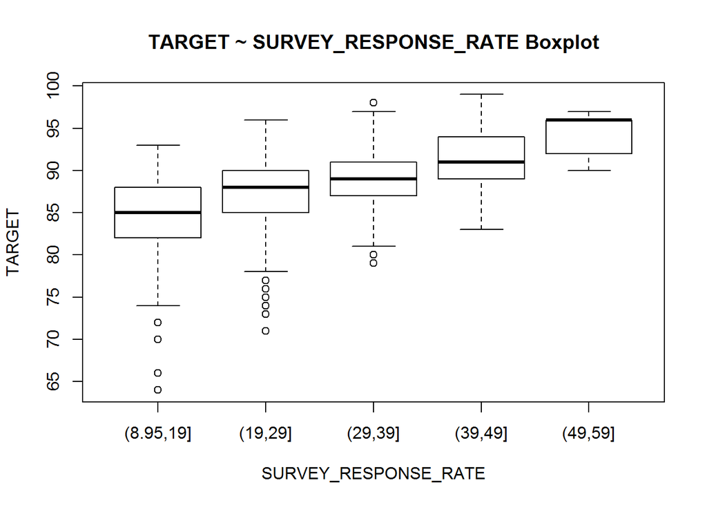

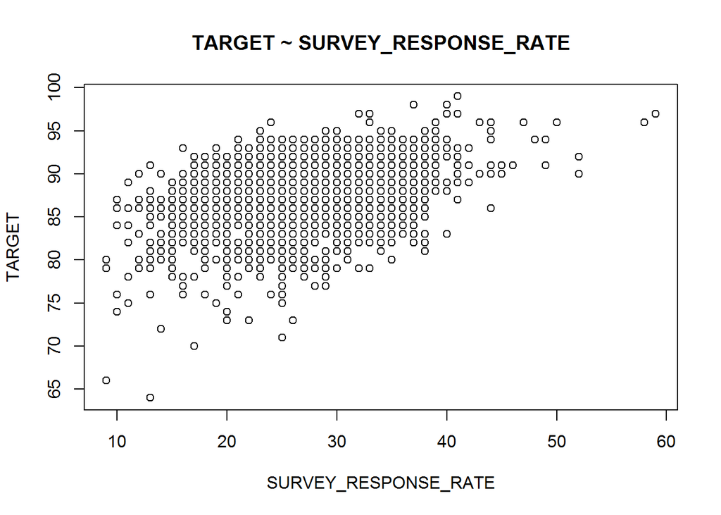

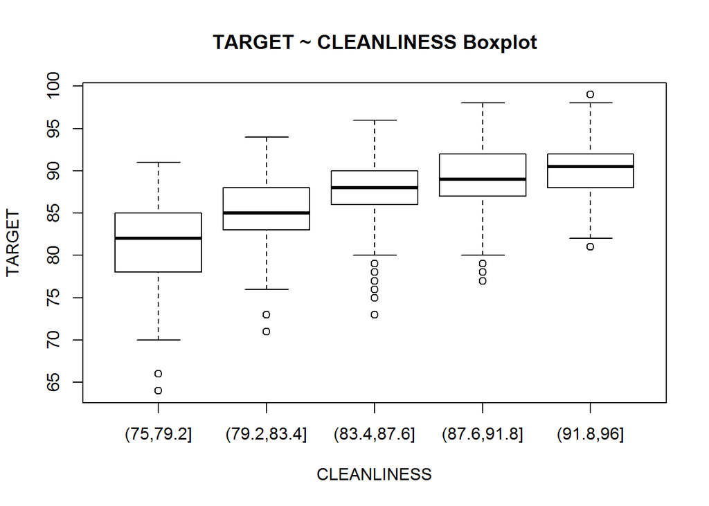

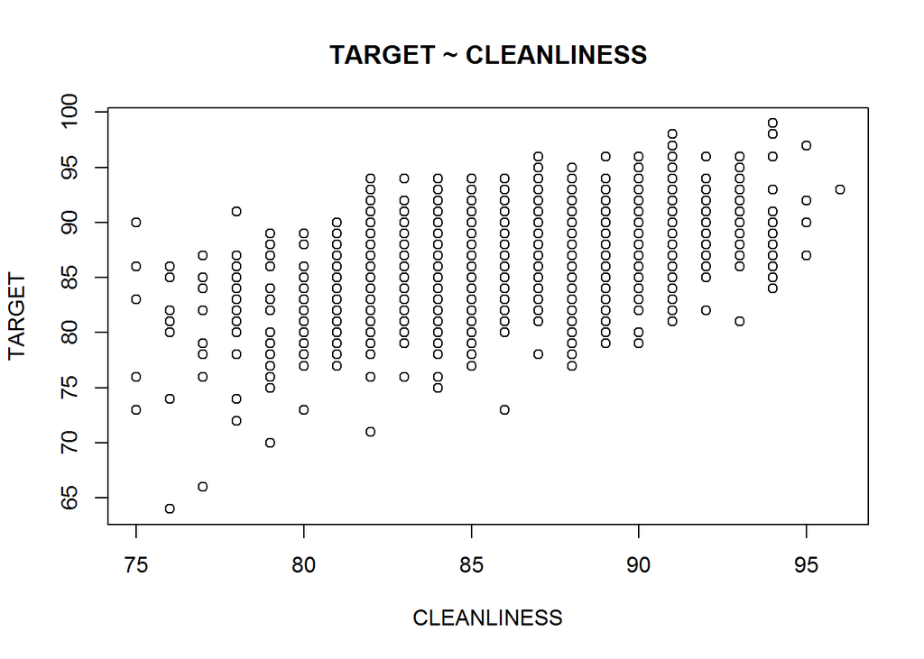

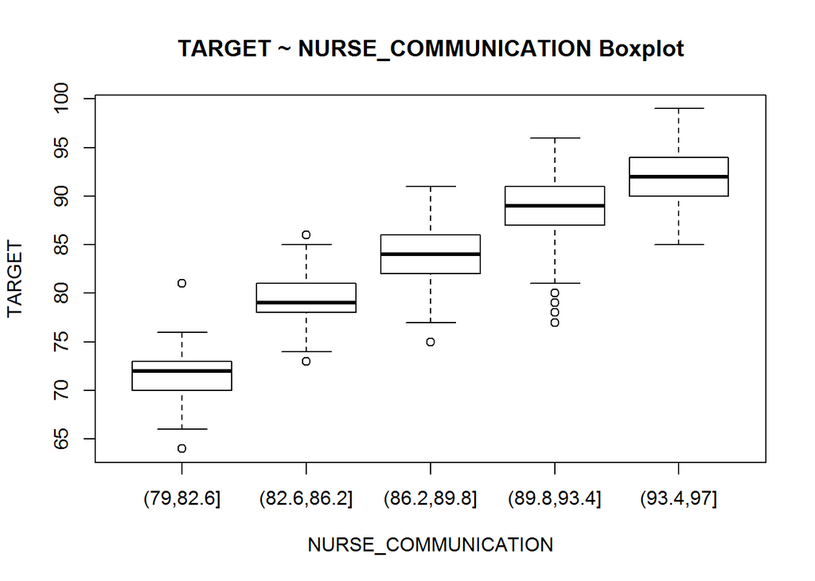

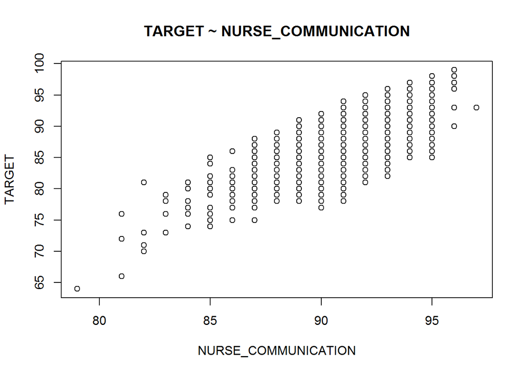

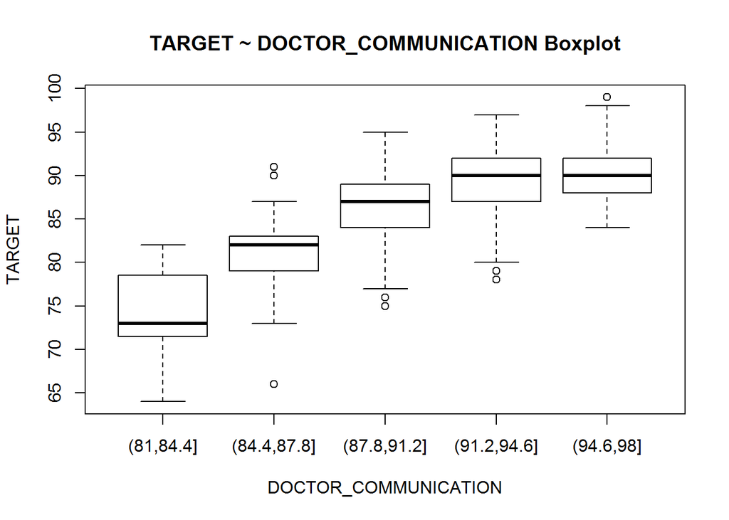

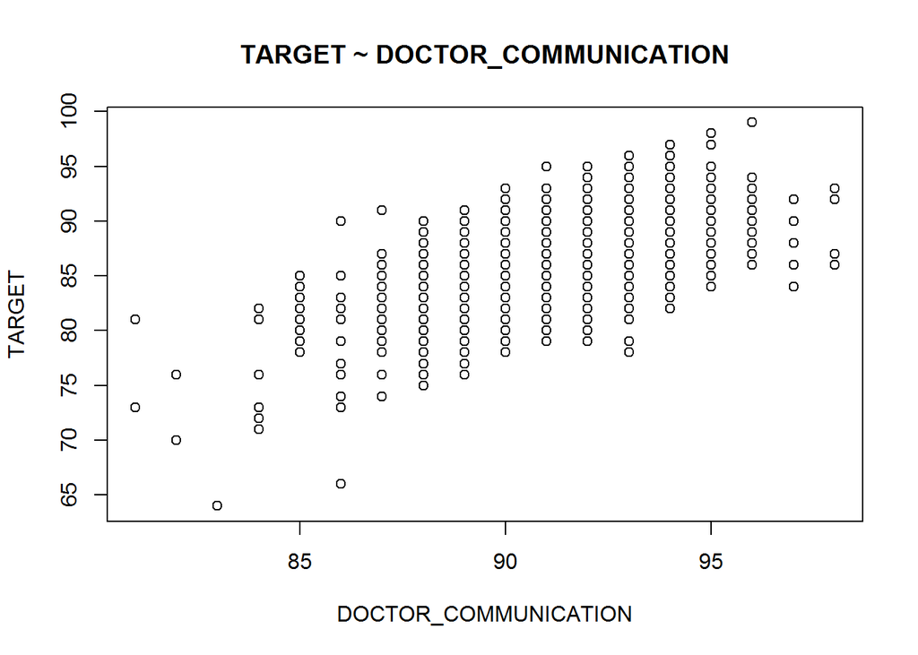

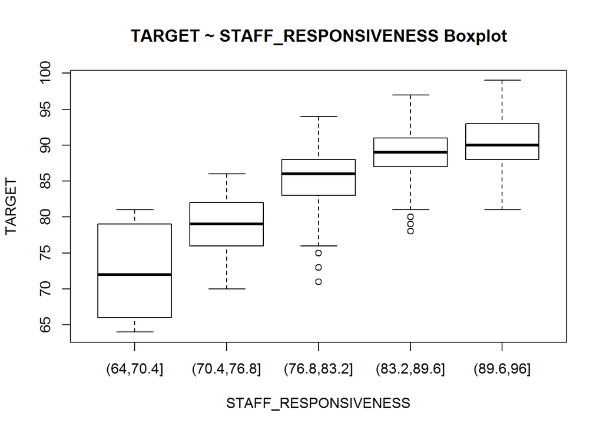

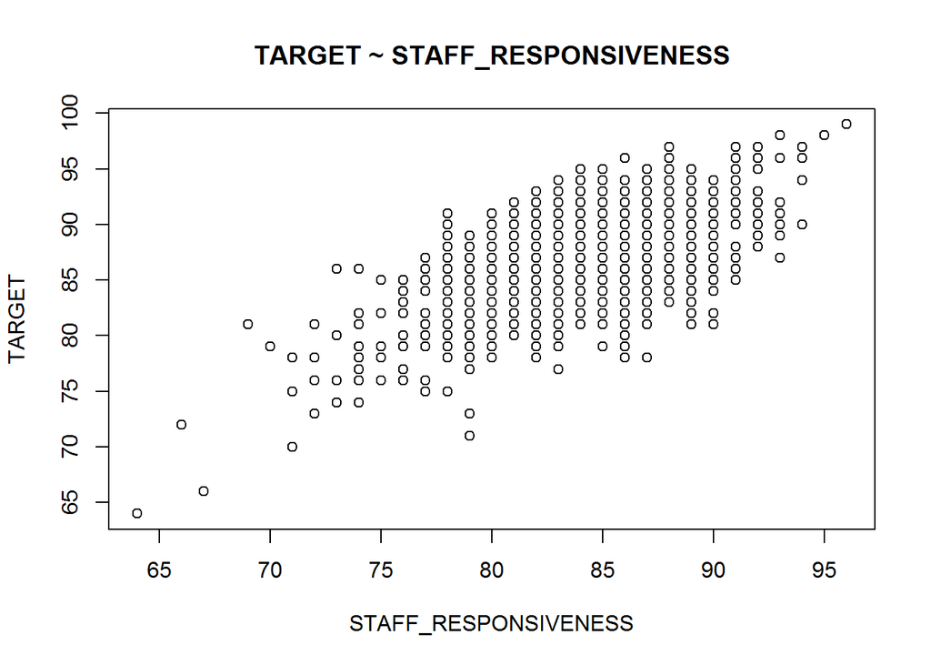

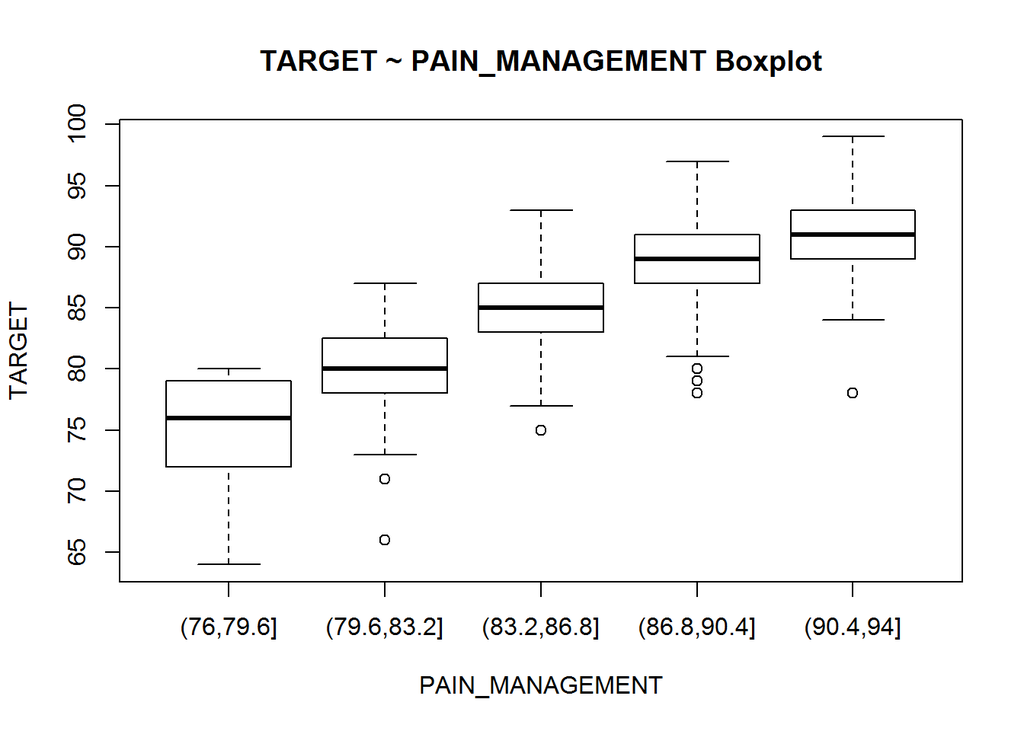

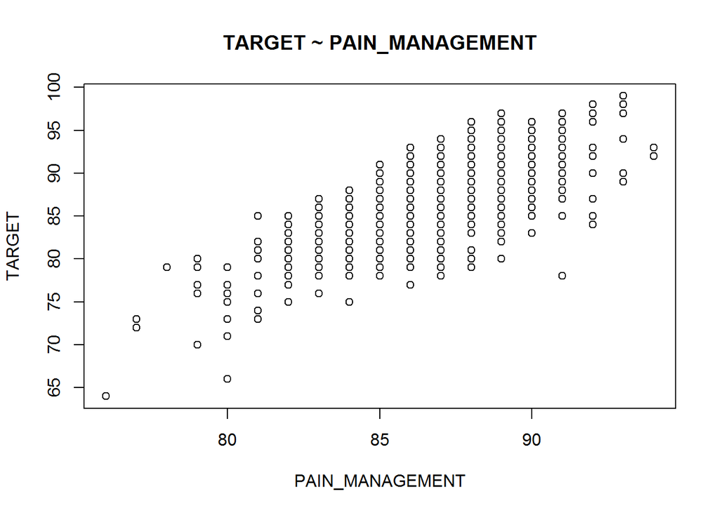

[12 more figures not shown]

```r
numResponse <- function(col,d){
    data <- d
    data <- data[order(data[,col]),c(col,target_lm)]
    x <- data[,col]
    y <- data[,target_lm]

    plot(y~cut(x,5), main=paste0("TARGET ~ ",col," Boxplot"),xlab=col, ylab="TARGET")
    plot(y~x, main=paste0("TARGET ~ ",col),xlab=col, ylab="TARGET")

}
View(training_trans[,inputs_num])
sapply(inputs_num,function(x){numResponse(x,training_trans)})
```

```r
#sapply(inputs_num,function(x){numResponse(x,evaluation_trans)})
```

##### **TARGET_NUM**

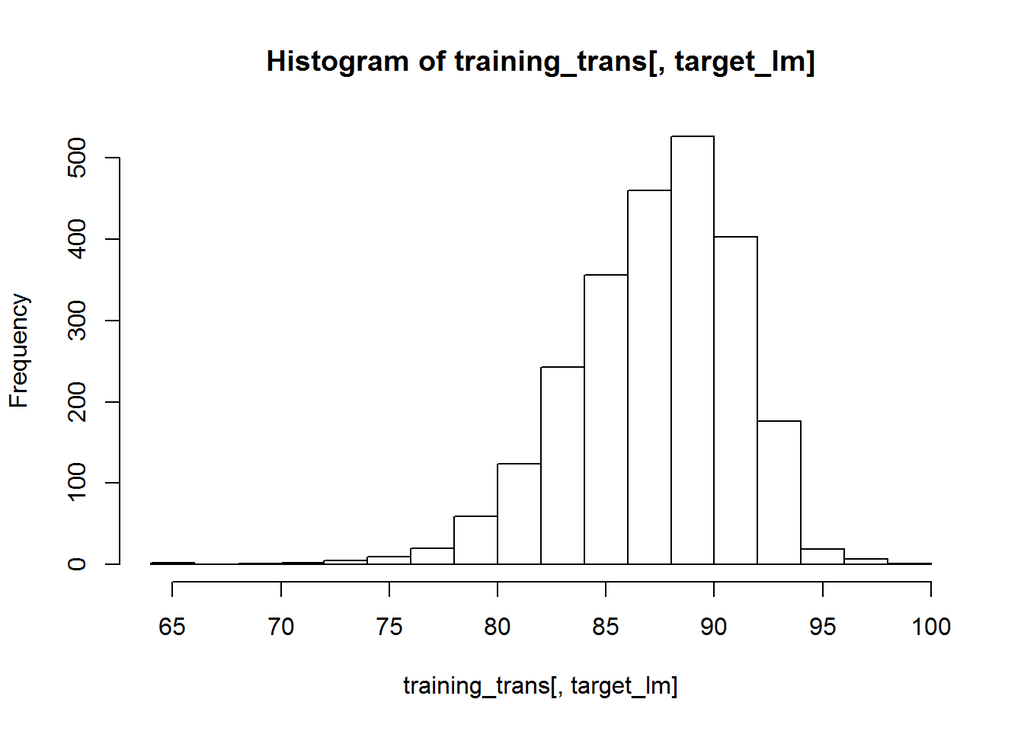

```r
hist(training_trans[,target_lm])
```

#### Final summary

```r
summary <- describe(training_trans[,c(target,inputs)])[,c("n","mean","sd","median","min","max")]
summary$completeness <- summary$n/nrow(training_trans)
summary$cv <- 100*summary$sd/summary$mean

kable(summary)
```

|  | n | mean | sd | median | min | max | completeness | cv |
| --- | --- | --- | --- | --- | --- | --- | --- | --- |
| TARGET_NUM | 2414 | 87.7365369 | 3.8751997 | 88 | 64 | 99 | 1 | 4.416860 |
| TYPE_CRITICAL_ACCESS_HOSPITALS_BIN | 2414 | 0.0078708 | 0.0883858 | 0 | 0 | 1 | 1 | 1122.964249 |
| TYPE_CHILDRENS_BIN | 2414 | 0.0000000 | 0.0000000 | 0 | 0 | 0 | 1 | NaN |
| OWNERSHIP_PRIVATE_BIN | 2414 | 0.4577465 | 0.4983147 | 0 | 0 | 1 | 1 | 108.862588 |
| OWNERSHIP_PROPRIETARY_BIN | 2414 | 0.1727423 | 0.3781027 | 0 | 0 | 1 | 1 | 218.882468 |
| OWNERSHIP_GOV_STATE_BIN | 2414 | 0.0144988 | 0.1195595 | 0 | 0 | 1 | 1 | 824.618684 |
| OWNERSHIP_OTHER_BIN | 2414 | 0.1197183 | 0.3246991 | 0 | 0 | 1 | 1 | 271.219254 |
| OWNERSHIP_GOV_LOCAL_BIN | 2414 | 0.0492958 | 0.2165297 | 0 | 0 | 1 | 1 | 439.246021 |
| OWNERSHIP_CHURCH_BIN | 2414 | 0.1035626 | 0.3047554 | 0 | 0 | 1 | 1 | 294.271766 |
| OWNERSHIP_GOV_FEDERAL_BIN | 2414 | 0.0028998 | 0.0537823 | 0 | 0 | 1 | 1 | 1854.722741 |
| OWNERSHIP_TRIBAL_BIN | 2414 | 0.0000000 | 0.0000000 | 0 | 0 | 0 | 1 | NaN |
| OWNERSHIP_PHYSICIAN_BIN | 2414 | 0.0028998 | 0.0537823 | 0 | 0 | 1 | 1 | 1854.722741 |
| EMERGENCY_SVC_BIN | 2414 | 0.9900580 | 0.0992333 | 1 | 0 | 1 | 1 | 10.022975 |
| MORTALITY_SAME_NTL_BIN | 2414 | 0.7075394 | 0.4549870 | 1 | 0 | 1 | 1 | 64.305540 |
| MORTALITY_ABOVE_NTL_BIN | 2414 | 0.1549296 | 0.3619125 | 0 | 0 | 1 | 1 | 233.598072 |
| SAFETY_OF_CARE_SAME_NTL_BIN | 2414 | 0.4345485 | 0.4958003 | 0 | 0 | 1 | 1 | 114.095510 |
| SAFETY_OF_CARE_ABOVE_NTL_BIN | 2414 | 0.3015742 | 0.4590365 | 0 | 0 | 1 | 1 | 152.213463 |
| READM_SAME_NTL_BIN | 2414 | 0.3732394 | 0.4837651 | 0 | 0 | 1 | 1 | 129.612546 |
| READM_ABOVE_NTL_BIN | 2414 | 0.3090307 | 0.4621896 | 0 | 0 | 1 | 1 | 149.561076 |
| EFFECTIVENESS_OF_CARE_SAME_NTL_BIN | 2414 | 0.5190555 | 0.4997403 | 1 | 0 | 1 | 1 | 96.278773 |
| EFFECTIVENESS_OF_CARE_ABOVE_NTL_BIN | 2414 | 0.3715824 | 0.4833277 | 0 | 0 | 1 | 1 | 130.072815 |
| TIMELINESS_OF_CARE_SAME_NTL_BIN | 2414 | 0.4117647 | 0.4922549 | 0 | 0 | 1 | 1 | 119.547625 |
| TIMELINESS_OF_CARE_ABOVE_NTL_BIN | 2414 | 0.2502071 | 0.4332220 | 0 | 0 | 1 | 1 | 173.145333 |
| EFFICIENCY_OF_USE_MEDICAL_IMAGING_EQUIPMENT_SAME_NTL_BIN | 2414 | 0.7178956 | 0.4501171 | 1 | 0 | 1 | 1 | 62.699524 |
| EFFICIENCY_OF_USE_MEDICAL_IMAGING_EQUIPMENT_ABOVE_NTL_BIN | 2414 | 0.1478873 | 0.3550618 | 0 | 0 | 1 | 1 | 240.089413 |
| SURVEY_RESPONSE_RATE | 2414 | 27.2448219 | 6.1123719 | 27 | 9 | 59 | 1 | 22.434986 |
| CLEANLINESS | 2414 | 86.5236123 | 3.3774903 | 87 | 75 | 96 | 1 | 3.903548 |
| NURSE_COMMUNICATION | 2414 | 91.0004143 | 2.0781459 | 91 | 79 | 97 | 1 | 2.283666 |
| DOCTOR_COMMUNICATION | 2414 | 91.4523612 | 1.9894064 | 92 | 81 | 98 | 1 | 2.175347 |
| STAFF_RESPONSIVENESS | 2414 | 84.3529412 | 3.5366352 | 85 | 64 | 96 | 1 | 4.192664 |
| PAIN_MANAGEMENT | 2414 | 87.2228666 | 2.0794515 | 87 | 76 | 94 | 1 | 2.384067 |
| MEDICATION_COMMUNICATION | 2414 | 78.0049710 | 3.4223335 | 78 | 62 | 92 | 1 | 4.387327 |
| DISCHARGE_INFO | 2414 | 86.7125104 | 3.0586532 | 87 | 68 | 95 | 1 | 3.527349 |
| CARE_TRANSITION | 2414 | 81.1710853 | 2.3371397 | 81 | 69 | 92 | 1 | 2.879276 |
| HOSPITAL_RATING | 2414 | 88.3227009 | 2.7702175 | 89 | 72 | 98 | 1 | 3.136473 |
| QUIETNESS | 2414 | 82.0907208 | 4.4948344 | 83 | 64 | 93 | 1 | 5.475447 |
| HOSPITAL_OVERALL_RTG | 2414 | 2.9954432 | 0.8605528 | 3 | 1 | 5 | 1 | 28.728730 |

```r
#head(training_trans)
#summary(training_trans)
```

### How are the input values distributed?, do we need to do something about them?

# Numerical target variable - RECOMEND HOSPITAL

```r
require("reshape2")
```

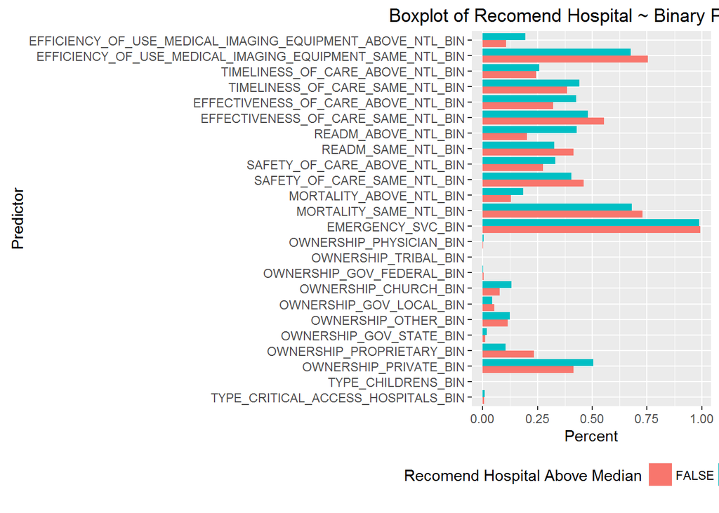

```r
require("ggplot2")
#detach(package:plyr)
require("dplyr")

training_normalized <- cbind(data.frame(scale(training_trans[,inputs_num])),training_trans[,c(inputs_bin,target)])
training_normalized$TARGET_FLAG <- training_normalized$TARGET > median(training_normalized$TARGET)

#training_normalized$TARGET_CUT <- cut(training_normalized$TARGET,2)


bin_summary <- melt(training_normalized[,c(inputs_bin,"TARGET_FLAG")], measure.vars = inputs_bin) %>%
  group_by(TARGET_FLAG,variable) %>%
  summarise(pct = sum(value)/length(value))

ggplot(bin_summary, aes(variable, pct)) +
  geom_bar(aes(fill = TARGET_FLAG), position = "dodge", stat="identity")+
  guides(fill=guide_legend(title="Recomend Hospital Above Median")) +
   theme(legend.position="bottom")+
    coord_flip()+
  labs(title="Boxplot of Recomend Hospital ~ Binary Predictors", y="Percent", x="Predictor")
```

possible correlations

```r
summary_positive <- describe(training_normalized[training_normalized$TARGET_FLAG,c(inputs)])[,c("mean","n")]
summary_negative <- describe(training_normalized[!training_normalized$TARGET_FLAG,c(inputs)])[,c("mean","n")]
summary_by_target <- merge(summary_positive,summary_negative,by="row.names")
colnames(summary_by_target) <- c("Variable","Above Median Recomend Hospital - Avg","Above Median Recomend Hospital - n","Below Median Recomend Hospital - Avg", "Below Median Recomend Hospital - n")
summary_by_target$delta <- abs(summary_by_target[,"Above Median Recomend Hospital - Avg"]-summary_by_target[,"Below Median Recomend Hospital - Avg"])

kable(summary_by_target[order(-summary_by_target$delta),])
```

|  | Variable | Above Median Recomend Hospital - Avg | Above Median Recomend Hospital - n | Below Median Recomend Hospital - Avg | Below Median Recomend Hospital - n | delta |
| --- | --- | --- | --- | --- | --- | --- |
| 11 | HOSPITAL_RATING | 0.7492946 | 1132 | -0.6616236 | 1282 | 1.4109182 |
| 1 | CARE_TRANSITION | 0.6457152 | 1132 | -0.5701635 | 1282 | 1.2158787 |
| 15 | NURSE_COMMUNICATION | 0.5447618 | 1132 | -0.4810222 | 1282 | 1.0257840 |
| 25 | PAIN_MANAGEMENT | 0.5202832 | 1132 | -0.4594076 | 1282 | 0.9796909 |
| 12 | MEDICATION_COMMUNICATION | 0.4647225 | 1132 | -0.4103478 | 1282 | 0.8750703 |
| 10 | HOSPITAL_OVERALL_RTG | 0.4518402 | 1132 | -0.3989728 | 1282 | 0.8508130 |
| 31 | STAFF_RESPONSIVENESS | 0.4379876 | 1132 | -0.3867410 | 1282 | 0.8247286 |
| 4 | DOCTOR_COMMUNICATION | 0.4333586 | 1132 | -0.3826536 | 1282 | 0.8160122 |
| 3 | DISCHARGE_INFO | 0.4290204 | 1132 | -0.3788230 | 1282 | 0.8078434 |
| 2 | CLEANLINESS | 0.3714759 | 1132 | -0.3280115 | 1282 | 0.6994874 |
| 26 | QUIETNESS | 0.3263078 | 1132 | -0.2881283 | 1282 | 0.6144361 |
| 32 | SURVEY_RESPONSE_RATE | 0.3203925 | 1132 | -0.2829051 | 1282 | 0.6032976 |
| 27 | READM_ABOVE_NTL_BIN | 0.4293286 | 1132 | 0.2028081 | 1282 | 0.2265205 |
| 23 | OWNERSHIP_PROPRIETARY_BIN | 0.1042403 | 1132 | 0.2332293 | 1282 | 0.1289890 |
| 5 | EFFECTIVENESS_OF_CARE_ABOVE_NTL_BIN | 0.4266784 | 1132 | 0.3229329 | 1282 | 0.1037455 |
| 22 | OWNERSHIP_PRIVATE_BIN | 0.5061837 | 1132 | 0.4149766 | 1282 | 0.0912071 |
| 28 | READM_SAME_NTL_BIN | 0.3259717 | 1132 | 0.4149766 | 1282 | 0.0890049 |
| 7 | EFFICIENCY_OF_USE_MEDICAL_IMAGING_EQUIPMENT_ABOVE_NTL_BIN | 0.1943463 | 1132 | 0.1068643 | 1282 | 0.0874820 |
| 8 | EFFICIENCY_OF_USE_MEDICAL_IMAGING_EQUIPMENT_SAME_NTL_BIN | 0.6766784 | 1132 | 0.7542902 | 1282 | 0.0776117 |
| 6 | EFFECTIVENESS_OF_CARE_SAME_NTL_BIN | 0.4796820 | 1132 | 0.5538222 | 1282 | 0.0741402 |
| 29 | SAFETY_OF_CARE_ABOVE_NTL_BIN | 0.3321555 | 1132 | 0.2745710 | 1282 | 0.0575845 |
| 30 | SAFETY_OF_CARE_SAME_NTL_BIN | 0.4045936 | 1132 | 0.4609984 | 1282 | 0.0564048 |
| 34 | TIMELINESS_OF_CARE_SAME_NTL_BIN | 0.4416961 | 1132 | 0.3853354 | 1282 | 0.0563607 |
| 13 | MORTALITY_ABOVE_NTL_BIN | 0.1846290 | 1132 | 0.1287051 | 1282 | 0.0559238 |
| 16 | OWNERSHIP_CHURCH_BIN | 0.1325088 | 1132 | 0.0780031 | 1282 | 0.0545057 |
| 14 | MORTALITY_SAME_NTL_BIN | 0.6819788 | 1132 | 0.7301092 | 1282 | 0.0481304 |
| 33 | TIMELINESS_OF_CARE_ABOVE_NTL_BIN | 0.2579505 | 1132 | 0.2433697 | 1282 | 0.0145808 |
| 18 | OWNERSHIP_GOV_LOCAL_BIN | 0.0432862 | 1132 | 0.0546022 | 1282 | 0.0113160 |
| 20 | OWNERSHIP_OTHER_BIN | 0.1245583 | 1132 | 0.1154446 | 1282 | 0.0091137 |
| 19 | OWNERSHIP_GOV_STATE_BIN | 0.0185512 | 1132 | 0.0109204 | 1282 | 0.0076308 |
| 9 | EMERGENCY_SVC_BIN | 0.9876325 | 1132 | 0.9921997 | 1282 | 0.0045672 |
| 21 | OWNERSHIP_PHYSICIAN_BIN | 0.0044170 | 1132 | 0.0015601 | 1282 | 0.0028569 |
| 17 | OWNERSHIP_GOV_FEDERAL_BIN | 0.0017668 | 1132 | 0.0039002 | 1282 | 0.0021334 |
| 36 | TYPE_CRITICAL_ACCESS_HOSPITALS_BIN | 0.0088339 | 1132 | 0.0070203 | 1282 | 0.0018136 |
| 24 | OWNERSHIP_TRIBAL_BIN | 0.0000000 | 1132 | 0.0000000 | 1282 | 0.0000000 |
| 35 | TYPE_CHILDRENS_BIN | 0.0000000 | 1132 | 0.0000000 | 1282 | 0.0000000 |